# DMA_Project_Python

```python
#installing the mysql module
pip install mysql-connector-python
```

[output not shown]

```python
pip install waterfallcharts
```

```python
pip install nbconvert
```

```python
#importing the mysql module
import mysql.connector as sql
from mysql.connector import Error
import numpy as np
import pandas as pd
import matplotlib.pyplot as plt
import seaborn as sns
import waterfall_chart
import warnings
warnings.filterwarnings('ignore')
```

```python
#creating connection with the localhost and connecting to the foodpro database inside the mysql localhost instance
cnx = sql.connect(
    host = "localhost",
    database = "foodpro",
    port = 3306,
    user = "root",
    password = "rootuser")
```

```python
#checking if the connection was completed successfully
cur = cnx.cursor()
cur.execute("SELECT CURDATE()")
row = cur.fetchone()
print("Current date is: {0}".format(row[0]))
cur.close()
cnx.close()
```

```
Current date is: 2022-12-04
```

```python
cnx = sql.connect(
    host = "localhost",
    database = "foodpro",
    port = 3306,
    user = "root",
    password = "rootuser")

try:
    sql_select_Query = "SELECT * FROM discount;"
    cursor = cnx.cursor()
    cursor.execute(sql_select_Query)
    records = cursor.fetchall()
    print("Different Gold Subscriptions Plans:\n")
    for i, row in enumerate(records):
        print(f'Plan {i + 1} =',row,"\n")
#
except Error as e:
    print("Error while connecting to MySQL", e)

finally:
    if (cnx.is_connected()):
        cursor.close()
        cnx.close()
        print("MySQL connection is closed")
```

```
Different Gold Subscriptions Plans:

Plan 1 = ('d_gold', 'gold_user', 6, 15)

Plan 2 = ('d_gold_plus', 'gold_plus_user', 10, 35)

Plan 3 = ('d_gold_pro', 'gold_pro_user', 14, 100)

Plan 4 = ('not applicable', 'no discount', 0, 0)

MySQL connection is closed
```

```python
cnx = sql.connect(
    host = "localhost",
    database = "foodpro",
    port = 3306,
    user = "root",
    password = "rootuser")

try:
    sql_select_Query = '''  SELECT d.discount_name, p.amount_paid
                            FROM discount d, orders o, payment p
                            WHERE o.discount_id = d.discount_id AND p.order_id = o.order_id;  '''
    cursor = cnx.cursor()
    cursor.execute(sql_select_Query)
    records = cursor.fetchall()

    print("The discounts availed on individual orders and the respective amount paid by the customer who made the order\n")
    for i, row in enumerate(records):
        print(f'Record {i + 1} =',row,"\n")
#
except Error as e:
    print("Error while connecting to MySQL", e)

finally:
    if (cnx.is_connected()):
        cursor.close()
        cnx.close()
        print("MySQL connection is closed")
```

```
The discounts availed on individual orders and the respective amount paid by the customer who made the order

Record 1 = ('gold_user', 586.56)

Record 2 = ('gold_user', 201.63)

Record 3 = ('gold_user', 711.345)

Record 4 = ('gold_user', 283.41)

Record 5 = ('gold_user', 362.84)

Record 6 = ('gold_user', 315.84)

Record 7 = ('gold_user', 157.92)

Record 8 = ('gold_user', 217.14)

Record 9 = ('gold_user', 89.488)

Record 10 = ('gold_user', 294.22)

Record 11 = ('gold_user', 300.8)

Record 12 = ('gold_user', 365.049)

Record 13 = ('gold_user', 259.44)

Record 14 = ('gold_user', 377.88)

Record 15 = ('gold_user', 383.52)

Record 16 = ('gold_user', 517.94)

Record 17 = ('gold_user', 286.7)

Record 18 = ('gold_user', 250.792)

Record 19 = ('gold_user', 497.025)

```

[output cut: 532 more lines]

```
Record 286 = ('no discount', 117.0)

Record 287 = ('no discount', 644.0)

Record 288 = ('no discount', 173.65)

Record 289 = ('no discount', 122.0)

Record 290 = ('no discount', 468.0)

Record 291 = ('no discount', 426.0)

Record 292 = ('no discount', 324.0)

MySQL connection is closed
```

```python
rec = {}
for i, j in records:
    if rec.get(i):
        rec[i].append(j)
    else:
        rec[i] = [j]
```

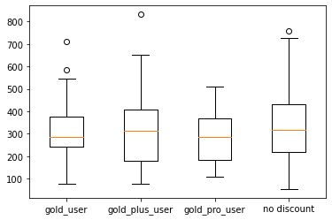

```python
fig, ax = plt.subplots()
ax.boxplot(rec.values())
ax.set_xticklabels(rec.keys());
```

The gold subscription plan users show lesser variations in their order ranges.

```python
#Now, lets look at the different dishes offered and the number of times they were ordered
cnx = sql.connect(
    host = "localhost",
    database = "foodpro",
    port = 3306,
    user = "root",
    password = "rootuser")

try:
    sql_select_Query = '''  SELECT mi.item_name, mi.item_type, CAST(SUM(od.quantity) AS SIGNED) no_of_units_ordered
FROM order_details od, menu_item mi
WHERE od.menu_id = mi.menu_id AND od.item_id = mi.item_id
GROUP BY mi.item_name
ORDER BY no_of_units_ordered DESC;  '''
    cursor = cnx.cursor()
    cursor.execute(sql_select_Query)
    records = cursor.fetchall()
    cols = cursor.description
    cols = [i[0] for i in cols]
    print(cols)
    print("The different food items and the number of times they were ordered are as follows:\n")
    for i, row in enumerate(records):
        print(f'Record {i + 1} =',row,"\n")



except Error as e:
    print("Error while connecting to MySQL", e)

finally:
    if (cnx.is_connected()):
        cursor.close()
        cnx.close()
        print("MySQL connection is closed")
```

```
['item_name', 'item_type', 'no_of_units_ordered']
The different food items and the number of times they were ordered are as follows:

Record 1 = ('Spaghetti with meatballs', 'main course', 353)

Record 2 = ('French fries', 'starter', 292)

Record 3 = ('Paneer Pesto', 'main course', 286)

Record 4 = ('Veg Pizza', 'fast food', 272)

Record 5 = ('Diet Coke', 'drinks', 271)

Record 6 = ('Chicken Pizza', 'fast food', 269)

Record 7 = ('Giant chocolate chip cookies', 'dessert', 268)

Record 8 = ('Baklava', 'dessert', 263)

Record 9 = ('Coke', 'drinks', 252)

Record 10 = ('Salad', 'main course', 229)

Record 11 = ('Fried chicken', 'main course', 214)

Record 12 = ('Onion rings', 'starter', 203)

MySQL connection is closed
```

```python
df_temp = pd.DataFrame(columns = cols, data = records)
df_temp
```

|  | item_name | item_type | no_of_units_ordered |
| --- | --- | --- | --- |
| 0 | Spaghetti with meatballs | main course | 353 |
| 1 | French fries | starter | 292 |
| 2 | Paneer Pesto | main course | 286 |
| 3 | Veg Pizza | fast food | 272 |
| 4 | Diet Coke | drinks | 271 |
| 5 | Chicken Pizza | fast food | 269 |
| 6 | Giant chocolate chip cookies | dessert | 268 |
| 7 | Baklava | dessert | 263 |
| 8 | Coke | drinks | 252 |
| 9 | Salad | main course | 229 |
| 10 | Fried chicken | main course | 214 |
| 11 | Onion rings | starter | 203 |

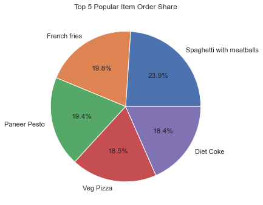

```python
fig, ax = plt.subplots(figsize=(6, 6))
ax.pie(df_temp.nlargest(5, 'no_of_units_ordered')['no_of_units_ordered'],
       labels = df_temp.nlargest(5, 'no_of_units_ordered')['item_name'], autopct = '%.1f%%')
ax.set_title('Top 5 Popular Item Order Share')
plt.tight_layout();
```

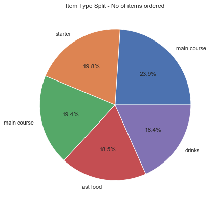

```python
fig, ax = plt.subplots(figsize=(6, 6))
ax.pie(df_temp.nlargest(5, 'no_of_units_ordered')['no_of_units_ordered'],
       labels = df_temp.nlargest(5, 'no_of_units_ordered')['item_type'], autopct = '%.1f%%')
ax.set_title('Item Type Split - No of items ordered')
plt.tight_layout();
```

```python
cnx = sql.connect(
    host = "localhost",
    database = "foodpro",
    port = 3306,
    user = "root",
    password = "rootuser")

try:
    sql_select_Query = '''  WITH t1
AS(SELECT DISTINCT YEARWEEK(CAST(STR_TO_DATE(CONCAT(LEFT(o.order_timestamp, 2), "-", SUBSTR(o.order_timestamp, 4, 7)), "%d-%m-%Y") AS DATE)) week_number,
		ROUND(SUM(od.cost) OVER (ORDER BY YEARWEEK(CAST(STR_TO_DATE(CONCAT(LEFT(o.order_timestamp, 2), "-",
        SUBSTR(o.order_timestamp, 4, 7)), "%d-%m-%Y") AS DATE))), 2) total_order_value

FROM order_details od, orders o
WHERE o.order_id = od.order_id),

t2 AS
(SELECT YEARWEEK(ga.start_date) week_number, SUM(d.subscription_fee) subscription_fee_collected
FROM gold_account ga, discount d
WHERE ga.discount_id = d.discount_id
GROUP BY 1
ORDER BY 1),

t3 AS
(SELECT DISTINCT YEARWEEK(CAST(STR_TO_DATE(CONCAT(LEFT(p.payment_timestamp, 2), "-", SUBSTR(p.payment_timestamp, 4, 7)), "%d-%m-%Y") AS DATE)) week_number,
		ROUND(SUM(p.amount_paid) OVER (ORDER BY YEARWEEK(CAST(STR_TO_DATE(CONCAT(LEFT(p.payment_timestamp, 2), "-",
        SUBSTR(p.payment_timestamp, 4, 7)), "%d-%m-%Y") AS DATE))), 2) total_order_value_after_discounts
FROM payment p),

t4 AS
(SELECT t1.week_number, t1.total_order_value, t3.total_order_value_after_discounts, t2.subscription_fee_collected
FROM t1
LEFT JOIN t2
ON t1.week_number = t2.week_number
LEFT JOIN t3
ON t2.week_number = t3.week_number),

t5 AS
(SELECT CONCAT("Year-", LEFT(t4.week_number, 4), ", ", "Week-", RIGHT(t4.week_number, 2)) AS week_number,
		t4.total_order_value, t4.total_order_value_after_discounts,
		ROUND((t4.total_order_value - t4.total_order_value_after_discounts), 2) total_discount_value,
        t4.subscription_fee_collected
FROM t4)

SELECT t5.week_number, CAST(t5.total_order_value AS SIGNED) total_order_value, t5.total_order_value_after_discounts, t5.total_discount_value,
		ROUND((t5.total_order_value * 0.14) + t5.subscription_fee_collected - t5.total_discount_value, 2) final_profit_value,
        CONCAT(ROUND(((ROUND((t5.total_order_value * 0.14) + t5.subscription_fee_collected - t5.total_discount_value, 2)) * 100)/
        (total_order_value), 2), "%") profit_divided_by_tot_ord_value
FROM t5;  '''
    cursor = cnx.cursor()
    cursor.execute(sql_select_Query)
    records = cursor.fetchall()

    cols = cursor.description
    cols = [i[0] for i in cols]

    print(cols)
    print("The cumulative balance sheet for the weeks are as follows\n")
    for i, row in enumerate(records):
        print(f'Record {i + 1} =',row,"\n")


except Error as e:
    print("Error while connecting to MySQL", e)

finally:
    if (cnx.is_connected()):
        cursor.close()
        cnx.close()
        print("MySQL connection is closed")
```

```
['week_number', 'total_order_value', 'total_order_value_after_discounts', 'total_discount_value', 'final_profit_value', 'profit_divided_by_tot_ord_value']
The cumulative balance sheet for the weeks are as follows

Record 1 = ('Year-2022, Week-39', 2933, None, None, None, None)

Record 2 = ('Year-2022, Week-40', 12391, 12004.82, 386.18, 1453.56, '11.73%')

Record 3 = ('Year-2022, Week-41', 21382, 20703.65, 678.35, 2710.13, '12.67%')

Record 4 = ('Year-2022, Week-42', 31208, 30156.05, 1051.95, 3437.17, '11.01%')

Record 5 = ('Year-2022, Week-43', 45298, 43726.72, 1571.28, 5270.44, '11.64%')

Record 6 = ('Year-2022, Week-44', 57127, 55092.1, 2034.9, 6012.88, '10.53%')

Record 7 = ('Year-2022, Week-45', 65347, 63023.47, 2323.53, 7010.05, '10.73%')

Record 8 = ('Year-2022, Week-46', 79510, 76632.73, 2877.27, 8459.13, '10.64%')

Record 9 = ('Year-2022, Week-47', 92991, 89563.4, 3427.6, 9706.14, '10.44%')

Record 10 = ('Year-2022, Week-48', 98828, 95145.77, 3682.23, 10203.69, '10.32%')

MySQL connection is closed
```

```python
#the individual record values are as follows
records
```

```
[('Year-2022, Week-39', 2933, None, None, None, None),
 ('Year-2022, Week-40', 12391, 12004.82, 386.18, 1453.56, '11.73%'),
 ('Year-2022, Week-41', 21382, 20703.65, 678.35, 2710.13, '12.67%'),
 ('Year-2022, Week-42', 31208, 30156.05, 1051.95, 3437.17, '11.01%'),
 ('Year-2022, Week-43', 45298, 43726.72, 1571.28, 5270.44, '11.64%'),
 ('Year-2022, Week-44', 57127, 55092.1, 2034.9, 6012.88, '10.53%'),
 ('Year-2022, Week-45', 65347, 63023.47, 2323.53, 7010.05, '10.73%'),
 ('Year-2022, Week-46', 79510, 76632.73, 2877.27, 8459.13, '10.64%'),
 ('Year-2022, Week-47', 92991, 89563.4, 3427.6, 9706.14, '10.44%'),
 ('Year-2022, Week-48', 98828, 95145.77, 3682.23, 10203.69, '10.32%')]
```

```python
#the column names are as follows
cols
```

```
['week_number',
 'total_order_value',
 'total_order_value_after_discounts',
 'total_discount_value',
 'final_profit_value',
 'profit_divided_by_tot_ord_value']
```

Lets visualise the mini balance sheet in a dataframe - Note that the values given are cumulative in nature and not the individual week values

```python
df_temp = pd.DataFrame(columns = cols, data = records)
```

```python
df_temp
```

|  | week_number | total_order_value | total_order_value_after_discounts | total_discount_value | final_profit_value | profit_divided_by_tot_ord_value |
| --- | --- | --- | --- | --- | --- | --- |
| 0 | Year-2022, Week-39 | 2933 | NaN | NaN | NaN | None |
| 1 | Year-2022, Week-40 | 12391 | 12004.82 | 386.18 | 1453.56 | 11.73% |
| 2 | Year-2022, Week-41 | 21382 | 20703.65 | 678.35 | 2710.13 | 12.67% |
| 3 | Year-2022, Week-42 | 31208 | 30156.05 | 1051.95 | 3437.17 | 11.01% |
| 4 | Year-2022, Week-43 | 45298 | 43726.72 | 1571.28 | 5270.44 | 11.64% |
| 5 | Year-2022, Week-44 | 57127 | 55092.10 | 2034.90 | 6012.88 | 10.53% |
| 6 | Year-2022, Week-45 | 65347 | 63023.47 | 2323.53 | 7010.05 | 10.73% |
| 7 | Year-2022, Week-46 | 79510 | 76632.73 | 2877.27 | 8459.13 | 10.64% |
| 8 | Year-2022, Week-47 | 92991 | 89563.40 | 3427.60 | 9706.14 | 10.44% |
| 9 | Year-2022, Week-48 | 98828 | 95145.77 | 3682.23 | 10203.69 | 10.32% |

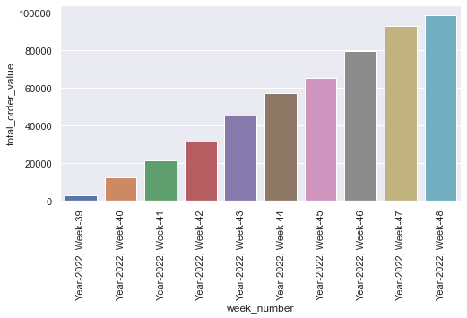

```python
sns.barplot(data = df_temp, x = 'week_number', y = 'total_order_value')
sns.set(rc = {"figure.figsize" : (8, 4)})
plt.xticks(rotation = 90)
plt.show();
```

The sales week over week have been consistently increasing which is a good sign. Considering the higher discounts (in terms of volume) offered to customers, it would be interesting to see if the graph pattern remains the same when looking into the final profit. Also, the order value is the highest for the combined consecutive week 46/47, this could be attributed to the thanksgiving week festivities. With people travelling from different places, and staying home, more orders can be expected around the holidays. We can further think about providing some extra discount during the holiday season to boost sales of both the orders as well as the subscriptions plans.

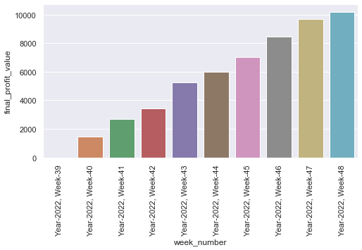

```python
sns.barplot(data = df_temp, x = 'week_number', y = 'final_profit_value')
sns.set(rc = {"figure.figsize" : (8, 4)})
plt.xticks(rotation = 90)
plt.show();
```

It seems like the profit values increased consistently in the first 8 weeks and then the increase rate reduced. So the final profit % considering a flat profit margin of 14% (on order value) is hovering around 10-11%. ALso, looking at the final profit values at a profit margin of 14%, we can clearly see that the final_profit per week is the highest for week 43, and a look at the profit percentages as a proportion of the total_order_value, we ca see that the profit % is highest for week 41, which can be attributed to the high number of gold subscriptions and the lesser discounts because fewer people were using the gold subscription discounts.

```python
#now, well try to visualize the average number of orders between gold and non gold customers
cnx = sql.connect(
    host = "localhost",
    database = "foodpro",
    port = 3306,
    user = "root",
    password = "rootuser")

try:
    sql_select_Query = '''  WITH non_disc AS
(SELECT o.order_id, ua.user_account_id, o.discount_id
FROM orders o, order_details od, user_account ua
WHERE o.order_id = od.order_id AND od.user_account_id = ua.user_account_id AND o.discount_id = 'not applicable'),

count_non_disc AS
(SELECT COUNT(DISTINCT non_disc.order_id) count_of_non_discounted_orders FROM non_disc),

count_disc AS
(SELECT COUNT(DISTINCT od.order_id) - count_non_disc.count_of_non_discounted_orders count_of_discounted_orders FROM order_details od, count_non_disc),

order_count AS
(SELECT count_non_disc.count_of_non_discounted_orders, count_disc.count_of_discounted_orders
FROM count_non_disc, count_disc
WHERE count_non_disc.count_of_non_discounted_orders IS NOT NULL)

SELECT CAST(ROUND((oc.count_of_non_discounted_orders/(SELECT COUNT(*) FROM free_account)), 2) AS DOUBLE) avg_order_per_free_user,
		CAST(ROUND((oc.count_of_discounted_orders/(SELECT COUNT(*) FROM gold_account)), 2) AS DOUBLE) avg_order_per_gold_user
FROM order_count oc; '''
    cursor = cnx.cursor()
    cursor.execute(sql_select_Query)
    records = cursor.fetchall()

    cols = cursor.description
    cols = [i[0] for i in cols]

    print("The average no of orders per gold customer and free account customer is as follows: \n")

    print(cols, '\n')
    for i, row in enumerate(records):
        print(f'Record {i + 1} =',row,"\n")



except Error as e:
    print("Error while connecting to MySQL", e)

finally:
    if (cnx.is_connected()):
        cursor.close()
        cnx.close()
        print("MySQL connection is closed")
```

```
The average no of orders per gold customer and free account customer is as follows:

['avg_order_per_free_user', 'avg_order_per_gold_user']

Record 1 = (1.53, 2.75)

MySQL connection is closed
```

```python
df_temp2 = pd.DataFrame(columns = cols, data = records)
df_temp2 = df_temp2.T.reset_index().rename(columns = {'index':'gold_vs_non_gold', 0:'Average order per User'})
df_temp2
```

|  | gold_vs_non_gold | Average order per User |
| --- | --- | --- |
| 0 | avg_order_per_free_user | 1.53 |
| 1 | avg_order_per_gold_user | 2.75 |

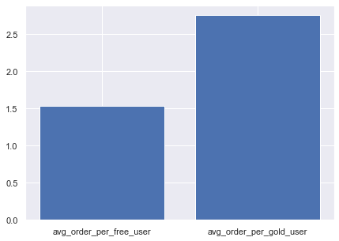

```python
plt.figure(figsize = (7, 5))
plt.bar(df_temp2['gold_vs_non_gold'] , df_temp2['Average order per User']);
```

The gold users order more often than the regular free user, this could be attributed to the fact that the gold user enjoys the discount associated with the gold account benifits

```python
#Now lets look at the average order value of gold and non gold customers
#now, well try to visualize the change in revenue/profit by looking at the income growth/decline in a waterfall graph
cnx = sql.connect(
    host = "localhost",
    database = "foodpro",
    port = 3306,
    user = "root",
    password = "rootuser")

try:
    sql_select_Query = '''  WITH tot_avg_val AS
(SELECT 1, od.order_id, SUM(cost) total_order_value
FROM order_details od
GROUP BY od.order_id),

gol_avg_val AS
(SELECT 1, ga.user_account_id, tot_avg_val.total_order_value
FROM tot_avg_val, order_details od2, user_account ua, gold_account ga
WHERE tot_avg_val.order_id = od2.order_id AND ua.user_account_id = od2.user_account_id AND ga.user_account_id = ua.user_account_id),

free_avg_val AS
(SELECT 1, fa.user_account_id, tot_avg_val.total_order_value
FROM tot_avg_val, order_details od2, user_account ua, free_account fa
WHERE tot_avg_val.order_id = od2.order_id AND ua.user_account_id = od2.user_account_id AND fa.user_account_id = ua.user_account_id),

t1 AS
(SELECT AVG(tot_avg_val.total_order_value) total_order_value FROM tot_avg_val),

t2 AS
(SELECT AVG(gol_avg_val.total_order_value) gold_total_order_value FROM gol_avg_val),

t3 AS
(SELECT AVG(free_avg_val.total_order_value) free_total_order_value FROM free_avg_val)

SELECT CAST(ROUND(t1.total_order_value, 2) AS SIGNED) cumulative_avg_order_value,
CAST(ROUND(t2.gold_total_order_value, 2) AS SIGNED) gold_avg_order_value,
		CAST(ROUND(t3.free_total_order_value, 2) AS SIGNED) free_avg_order_value
FROM t1, t2, t3
WHERE t1.total_order_value IS NOT NULL; '''
    cursor = cnx.cursor()
    cursor.execute(sql_select_Query)
    records = cursor.fetchall()

    cols = cursor.description
    cols = [i[0] for i in cols]

    print("The average no of orders per gold customer and free account customer is as follows: \n")

    print(cols, '\n')
    for i, row in enumerate(records):
        print(f'Record {i + 1} =',row,"\n")



except Error as e:
    print("Error while connecting to MySQL", e)

finally:
    if (cnx.is_connected()):
        cursor.close()
        cnx.close()
        print("MySQL connection is closed")
```

```
The average no of orders per gold customer and free account customer is as follows:

['cumulative_avg_order_value', 'gold_avg_order_value', 'free_avg_order_value']

Record 1 = (338, 357, 342)

MySQL connection is closed
```

```python
df_temp3 = pd.DataFrame(columns = cols, data = records)
df_temp3 = df_temp3.T.reset_index().rename(columns = {'index':'order_type', 0:'avg_order_value'})
df_temp3
```

|  | order_type | avg_order_value |
| --- | --- | --- |
| 0 | cumulative_avg_order_value | 338 |
| 1 | gold_avg_order_value | 357 |
| 2 | free_avg_order_value | 342 |

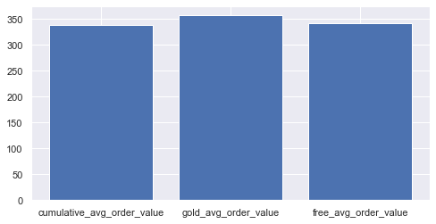

```python
plt.bar(df_temp3['order_type'], df_temp3['avg_order_value']);
```

We can see that the average order value of gold members is larger in comparison to the free account users. It would be interesting to see if the story remains even after we take into account the gold discount offered to the gold members

```python
#now, well try to visualize the change in revenue/profit by looking at the income growth/decline in a waterfall graph
cnx = sql.connect(
    host = "localhost",
    database = "foodpro",
    port = 3306,
    user = "root",
    password = "rootuser")

try:
    sql_select_Query = '''  WITH t1
AS(SELECT DISTINCT YEARWEEK(CAST(STR_TO_DATE(CONCAT(LEFT(o.order_timestamp, 2), "-", SUBSTR(o.order_timestamp, 4, 7)), "%d-%m-%Y") AS DATE)) week_number,
		ROUND(SUM(od.cost) OVER (PARTITION BY YEARWEEK(CAST(STR_TO_DATE(CONCAT(LEFT(o.order_timestamp, 2), "-",
        SUBSTR(o.order_timestamp, 4, 7)), "%d-%m-%Y") AS DATE))), 2) total_order_value

FROM order_details od, orders o
WHERE o.order_id = od.order_id),

t2 AS
(SELECT YEARWEEK(ga.start_date) week_number, SUM(d.subscription_fee) subscription_fee_collected
FROM gold_account ga, discount d
WHERE ga.discount_id = d.discount_id
GROUP BY 1
ORDER BY 1),

t3 AS
(SELECT DISTINCT YEARWEEK(CAST(STR_TO_DATE(CONCAT(LEFT(p.payment_timestamp, 2), "-", SUBSTR(p.payment_timestamp, 4, 7)), "%d-%m-%Y") AS DATE)) week_number,
		ROUND(SUM(p.amount_paid) OVER (PARTITION BY YEARWEEK(CAST(STR_TO_DATE(CONCAT(LEFT(p.payment_timestamp, 2), "-",
        SUBSTR(p.payment_timestamp, 4, 7)), "%d-%m-%Y") AS DATE))), 2) total_order_value_after_discounts
FROM payment p),

t4 AS
(SELECT t1.week_number, t1.total_order_value, t3.total_order_value_after_discounts, t2.subscription_fee_collected
FROM t1
LEFT JOIN t2
ON t1.week_number = t2.week_number
LEFT JOIN t3
ON t2.week_number = t3.week_number),

t5 AS
(SELECT CONCAT("Year-", LEFT(t4.week_number, 4), ", ", "Week-", RIGHT(t4.week_number, 2)) AS week_number,
		CAST(t4.total_order_value AS SIGNED) total_order_value, CAST(t4.total_order_value_after_discounts AS SIGNED)
        total_order_value_after_discounts,
		CAST(ROUND((t4.total_order_value - t4.total_order_value_after_discounts), 2) AS SIGNED) total_discount_value,
        CAST(t4.subscription_fee_collected AS SIGNED) subscription_fee_collected
FROM t4)

SELECT * FROM t5; '''
    cursor = cnx.cursor()
    cursor.execute(sql_select_Query)
    records = cursor.fetchall()

    cols = cursor.description
    cols = [i[0] for i in cols]

    print("The weekly revenue collected and other info are as follows: \n")

    print(cols, '\n')
    for i, row in enumerate(records):
        print(f'Record {i + 1} =',row,"\n")



except Error as e:
    print("Error while connecting to MySQL", e)

finally:
    if (cnx.is_connected()):
        cursor.close()
        cnx.close()
        print("MySQL connection is closed")
```

```
The weekly revenue collected and other info are as follows:

['week_number', 'total_order_value', 'total_order_value_after_discounts', 'total_discount_value', 'subscription_fee_collected']

Record 1 = ('Year-2022, Week-39', 2933, None, None, None)

Record 2 = ('Year-2022, Week-40', 9458, 9178, 280, 105)

Record 3 = ('Year-2022, Week-41', 8991, 8699, 292, 395)

Record 4 = ('Year-2022, Week-42', 9826, 9452, 374, 120)

Record 5 = ('Year-2022, Week-43', 14090, 13571, 519, 500)

Record 6 = ('Year-2022, Week-44', 11829, 11365, 464, 50)

Record 7 = ('Year-2022, Week-45', 8220, 7931, 289, 185)

Record 8 = ('Year-2022, Week-46', 14163, 13609, 554, 205)

Record 9 = ('Year-2022, Week-47', 13481, 12931, 550, 115)

Record 10 = ('Year-2022, Week-48', 5837, 5582, 255, 50)

MySQL connection is closed
```

```python
df_temp4 = pd.DataFrame(columns = cols, data = records)
df_temp4 = df_temp4.fillna(0)
df_temp4
```

|  | week_number | total_order_value | total_order_value_after_discounts | total_discount_value | subscription_fee_collected |
| --- | --- | --- | --- | --- | --- |
| 0 | Year-2022, Week-39 | 2933 | 0.0 | 0.0 | 0.0 |
| 1 | Year-2022, Week-40 | 9458 | 9178.0 | 280.0 | 105.0 |
| 2 | Year-2022, Week-41 | 8991 | 8699.0 | 292.0 | 395.0 |
| 3 | Year-2022, Week-42 | 9826 | 9452.0 | 374.0 | 120.0 |
| 4 | Year-2022, Week-43 | 14090 | 13571.0 | 519.0 | 500.0 |
| 5 | Year-2022, Week-44 | 11829 | 11365.0 | 464.0 | 50.0 |
| 6 | Year-2022, Week-45 | 8220 | 7931.0 | 289.0 | 185.0 |
| 7 | Year-2022, Week-46 | 14163 | 13609.0 | 554.0 | 205.0 |
| 8 | Year-2022, Week-47 | 13481 | 12931.0 | 550.0 | 115.0 |
| 9 | Year-2022, Week-48 | 5837 | 5582.0 | 255.0 | 50.0 |

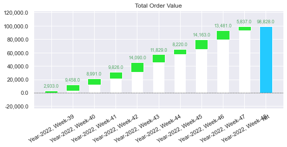

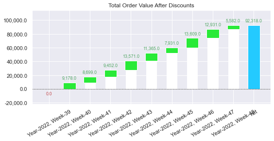

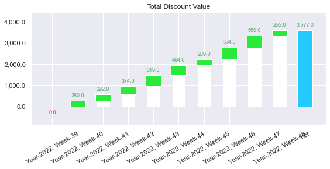

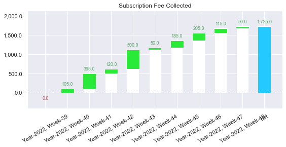

```python
for col in df_temp4.columns[1:]:
    plt.figure(figsize = (6, 6))
    waterfall_chart.plot(df_temp4.loc[:, 'week_number'], df_temp4.loc[:, col])
    plt.title(' '.join(str(col).strip().split('_')).title())
    plt.show();
```

The order value (with and without discount) and the discounts given show constant increase with the rate reducing in the latest weeks. The subscription fee collected has also reduced in comparison to the earlier days of the app. So, we can focus on revamping the subcription plan structure; think of new ways of incentivising buying a subcription plan, because it has clearly been established that gold users use the app to buy larger orders than non gold users.

```python
!jupyter nbconvert --to html DMA_Project_Python.ipynb
```